[figure not shown]

FU(w/o STI)-2

General Description

FUEL INJECTION (FUEL SYSTEMS)

1. General Description

A: SPECIFICATION

Fuel tank

Capacity 60 L (15.9 US gal, 13.2 Imp gal)

Location Under rear seat

Fuel pump

Type Impeller

Discharge rate

153 L (40.4 US gal, 33.7 Imp gal)/h or more

Fuel filter In-tank type

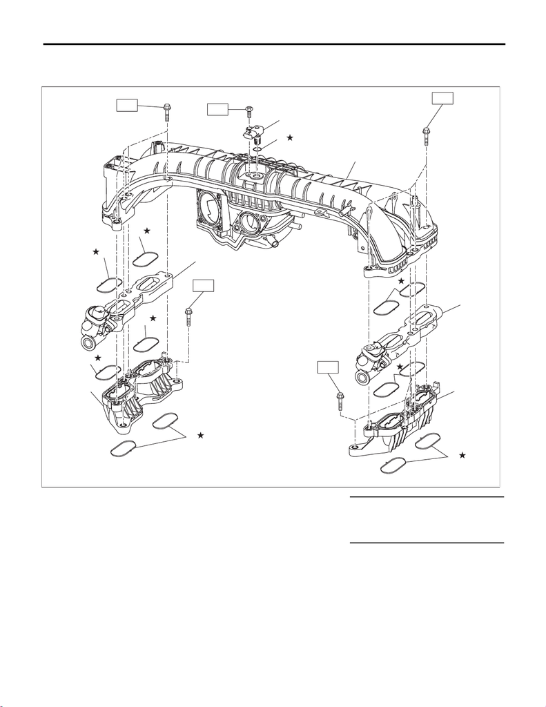

FU(w/o STI)-3

General Description

FUEL INJECTION (FUEL SYSTEMS)

B: COMPONENT

1. INTAKE MANIFOLD

(1) Intake manifold (6) Gasket Tightening torque: N·m (kgf-m, ft-lb)

(2) Manifold absolute pressure and

intake air temperature sensor

(7) Air intake adapter LH T1: 3.5 (0.4, 2.6)

(3) O-ring (8) Air intake adapter RH T2: 25 (2.5, 18.4)

(4) Tumble generator valve ASSY LH (9) Gasket

(5) Tumble generator valve ASSY RH

FU-07848

(1)

(2)

T1

T2

T2

T2

T2

(4)

(7)

(5)

(3)

(6)

(6)

(6)

(6)

(6)

(6)

(9)

(8)

(9)

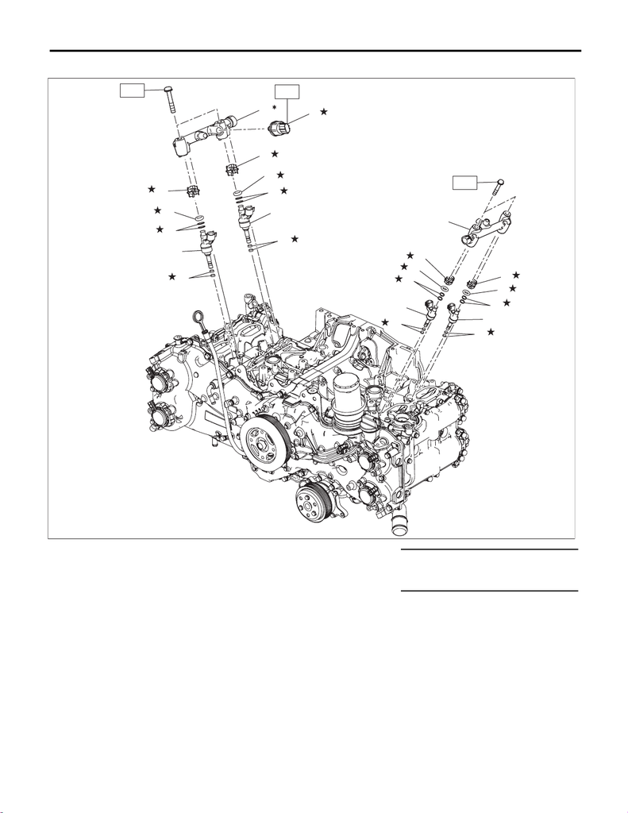

FU(w/o STI)-4

General Description

FUEL INJECTION (FUEL SYSTEMS)

2. FUEL INJECTOR 1

(1) Fuel injector pipe LH (5) Back-up ring Tightening torque: N·m (kgf-m, ft-lb)

(2) Fuel injector pipe RH (6) Fuel injector T1: 19 (1.9, 14.0)

(3) Holder (7) Injector seal T2: 46 (4.7, 33.9)

(4) O-ring (8) Fuel pressure sensor

* When removing the fuel pressure sensor from the fuel injector pipe RH, replace it with a new one.

FU-08465

(1)

(2)

(3)

(4)

T1

(5)

(3)

(4)

(6)

(5)

(6)

(8)

(5)

(5)

(6)

(4)

(4)

(6)

(7)

(7)

(7)

(7)

(3)

(3)

T2

T1

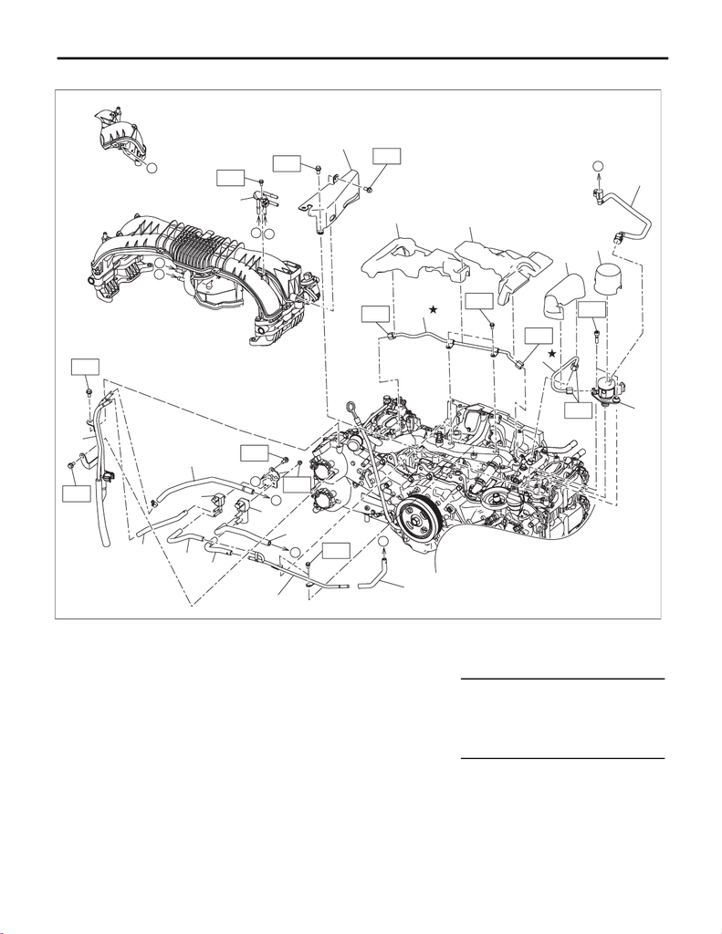

FU(w/o STI)-5

General Description

FUEL INJECTION (FUEL SYSTEMS)

3. FUEL INJECTOR 2

(1) Fuel pipe protector (10) Vacuum control hose (19) Vacuum pipe ASSY

(2) Fuel pipe insulator No. 3 (11) Purge control solenoid valve A (20) Fuel pipe ASSY

(3) Fuel pipe insulator No. 2 (12) Purge control solenoid valve B

(4) Fuel pipe insulator No. 1 (13) Vacuum hose A Tightening torque: N·m (kgf-m, ft-lb)

(5) Fuel pump insulator (14) Vacuum hose B T1: 6.4 (0.7, 4.7)

(6) Fuel delivery pipe (15) Vacuum hose C T2: 19 (1.9, 14.0)

(7) High-pressure fuel pump (16) Vacuum hose D T3: 21 (2.1, 15.5)

ASSY

(18) Vacuum hose E

B

C

B

F

D

D

E

E

C

T2

T1

T4

T4

T1

T2

T3

T1

(3)

(9)

(10)

(4)

(5)

(6)

(2)

(1)

(8)

(12)

(7)

(18)

(11)

(19)

(17)

(15)

(13)

T1

T1

(14)

(16)

T4

(20)

T2

T1

FU-08406

F

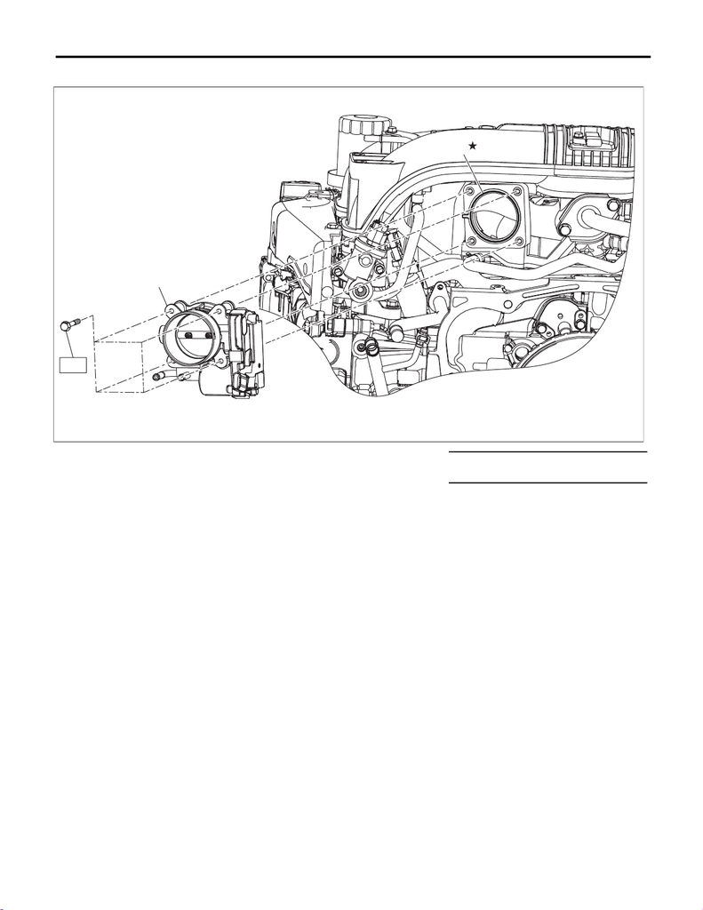

FU(w/o STI)-6

General Description

FUEL INJECTION (FUEL SYSTEMS)

4. THROTTLE BODY

(1) Throttle body (2) Gasket Tightening torque: N·m (kgf-m, ft-lb)

T: 8 (0.8, 5.9)

(1)

(2)

T

FU-07292

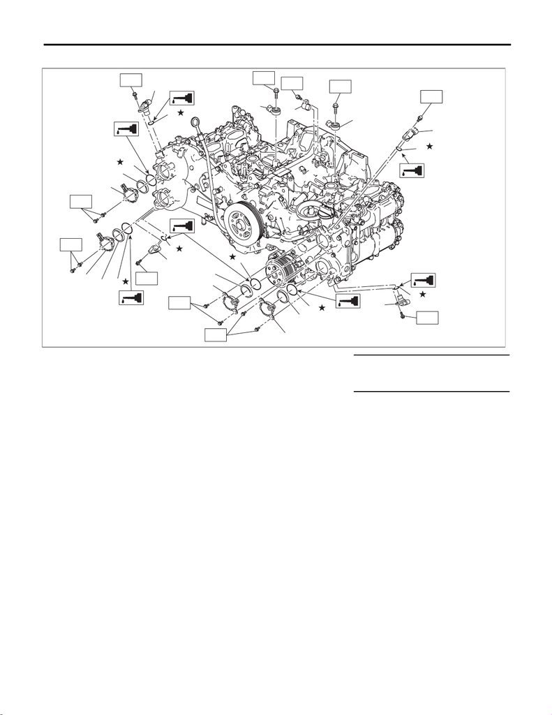

FU(w/o STI)-7

General Description

FUEL INJECTION (FUEL SYSTEMS)

5. CRANKSHAFT POSITION, CAMSHAFT POSITION AND KNOCK SENSORS

(1) Oil control solenoid (5) O-ring Tightening torque: N·m (kgf-m, ft-lb)

(2) Camshaft position sensor (6) Back-up ring T1: 6.4 (0.7, 4.7)

(3) Crankshaft position sensor (7) O-ring T2: 24 (2.4, 17.7)

(4) Knock sensor

(3)

(2)

(4)

(4)

(5)

(5)

T1

T1

T2

T2

T1

(6)

T1

T1

(1)

T1

(7)

(7)

(7)

(7)

T1

T1

T1

FU-08449

(1)

(1)

(1)

(2)

(2)

(2)

(6)

(6)

(5)

(6)

(5)

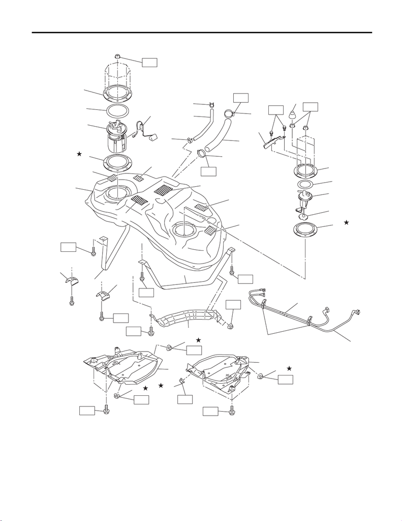

FU(w/o STI)-8

General Description

FUEL INJECTION (FUEL SYSTEMS)

6. FUEL TANK

FU-08300

T5

T5

T4

T5

(2)

(2)

(15)

(10)

(13)

(12)

(1)

T6

(6)

(8)

(7)

T7

(14)

(11)

(20)

T7

(9)

(21)

(22)

(23)

T1

T2

(24)

(25)

(25)

(28)

(27)

(5)

(29)

(31)

(29)

(30)

(31)

(30)

(3)

(4)

(26)

T4

(16)

T4

T4

(17)

T4

T3

T3

T3

T3

(18)

(19)

(19)

(19)

(19)

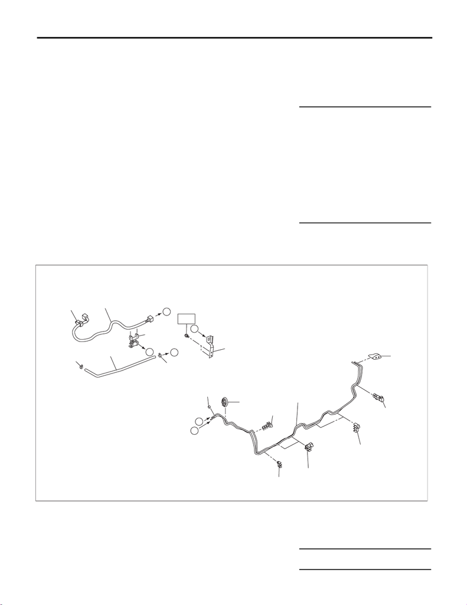

FU(w/o STI)-9

General Description

FUEL INJECTION (FUEL SYSTEMS)

7. FUEL LINE

• Fuel line 1

(1) Fuel tank (15) Stopper LH (28) Fuel sub level sensor upper plate

cushion

(2) Fuel tank band (16) Heat shield cover (29) Cushion

(3) Fuel delivery tube (17) Fuel tank protector RH (30) Cushion

(4) Jet pump tube (18) Fuel tank protector LH (31) Cushion

(5) Fuel pump ASSY (19) Self-locking nut

(6) Fuel pump upper plate (20) Rubber cap Tightening torque: N·m (kgf-m, ft-lb)

(7) Fuel pump gasket (21) Fuel filler hose T1: 2 (0.2, 1.5)

(8) Fuel level sensor (22) Clamp T2: 2.5 (0.3, 1.8)

(9) Fuel sub level sensor (23) Clamp T3: 9 (0.9, 6.6)

(10) Fuel sub level sensor upper plate (24) Evaporation hose T4: 18 (1.8, 13.3)

(11) Fuel sub level sensor gasket (25) Clip T5: <Ref. to FU(w/o STI)-157,

INSTALLATION, Fuel Tank.>

(12) Fuel sub level sensor filter (26) Tube clamp T6: <Ref. to FU(w/o STI)-171,

INSTALLATION, Fuel Pump.>

(13) Fuel sub level sensor protector (27) Fuel pump upper plate cushion T7: <Ref. to FU(w/o STI)-180,

INSTALLATION, Fuel Sub Level

Sensor.>

(14) Stopper RH

(1) Fuel delivery tube (7) Fuel pipe ASSY (13) Pipe clamp

(2) Evaporation hose (8) Bushing (14) Pipe clamp

(3) Tube clamp (9) Fuel pipe front grommet (15) Fuel pipe rear grommet

(4) Clip (10) Pipe clamp

(5) Hose clamp (11) Pipe clamp Tightening torque: N·m (kgf-m, ft-lb)

(6) Hose clamp bracket (12) Pipe clamp T: 7.5 (0.8, 5.5)

FU-08469

(7)

(3)

(6)

T

(4)

(1)

(4)

(5)

(2)

(9)

(8)

(11)

(10)

(12)

(13)

(14)

(15)

B

A

B

A

C

C

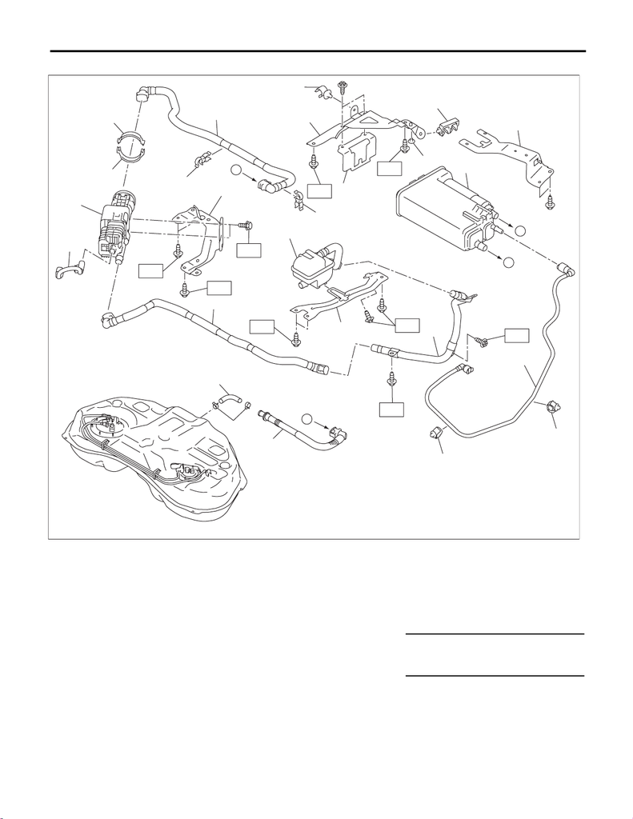

FU(w/o STI)-10

General Description

FUEL INJECTION (FUEL SYSTEMS)

• Fuel line 2

(1) Vent hose (11) Purge tube (20) Canister bracket B

(2) Clip (12) Tube clamp (21) Tube clamp

(3) Vent tube (13) Clamp B (22) Clip

(4) Harness (14) Clamp A (23) Canister bracket C

(5) Leak check valve ASSY (15) Drain tube B (24) Canister

(6) Leak check valve bracket (16) Tube clamp

(7) Drain tube A (17) Tube clamp Tightening torque: N·m (kgf-m, ft-lb)

(8) Drain filter (18) Canister bracket A T1: 5.4 (0.6, 4.0)

(9) Drain bracket (19) Tube clamp T2: 7.5 (0.8, 5.5)

(10) Drain pipe

*1 The canister bracket cannot be separated from the canister. Therefore, be sure to replace both of them with new ones when

replacing the canister or canister bracket.

*2 The drain filter cannot be separated from the drain bracket. Therefore, be sure to replace both of them with new ones when

replacing the drain bracket or drain filter.

FU-08473

(1)

(2)

(3)

(7)

(4)

(5)

(6)

T2

T1

T2

T2

T2

(8)

(9)

2

2

(10)

T2

T2

(11)

(12)

(12)

(13)

(14)

(15)

(16)

(17)

(18)

(19)

(20)

(21)

T2

T2

(22)

1

1

(23)

(24)

1

A

A

B

B

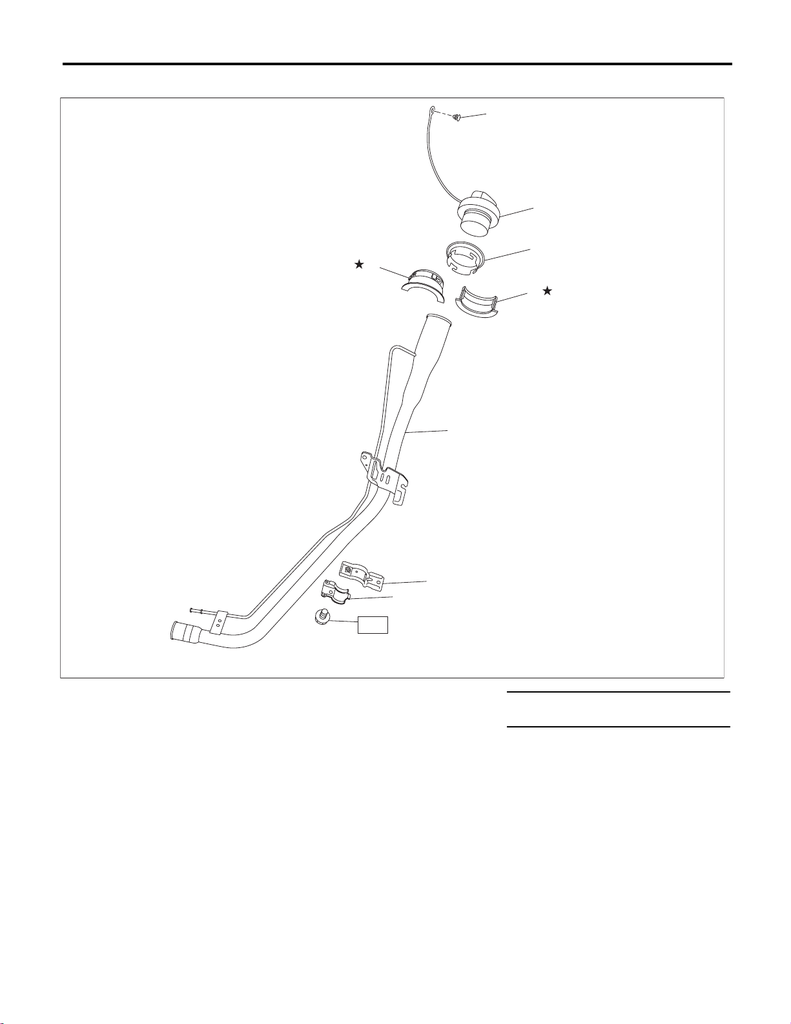

FU(w/o STI)-11

General Description

FUEL INJECTION (FUEL SYSTEMS)

8. FUEL FILLER PIPE

(1) Fuel filler pipe ASSY (5) Fuel filler cap Tightening torque: N·m (kgf-m, ft-lb)

(2) Neck holder A (6) Clip T: 7.35 (0.7, 5.4)

(3) Neck holder B (7) Upper bracket

(4) Fuel filler pipe protector (8) Lower bracket

FU-08448

T

(1)

(2)

(3)

(4)

(5)

(6)

(7)

(8)

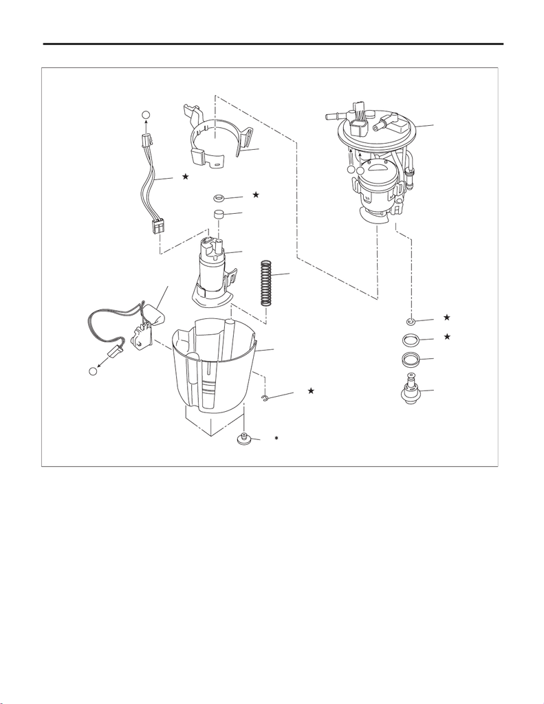

FU(w/o STI)-12

General Description

FUEL INJECTION (FUEL SYSTEMS)

9. FUEL PUMP

(1) Fuel filter ASSY (6) Connector cable (11) Spring

(2) O-ring (7) Fuel pump holder (12) Fuel chamber ASSY

(3) O-ring (8) O-ring (13) Clip

(4) Back-up ring (9) Spacer (14) Fuel level sensor

(5) Pressure regulator (10) Fuel pump (15) Cushion

* When removing the cushion from the fuel chamber assembly, replace it with a new part.

FU-08466

(15)

(10)

(12)

(14)

(7)

(2)

(3)

(4)

(5)

(1)

(8)

(9)

(11)

(6)

(13)

B

A

B

A

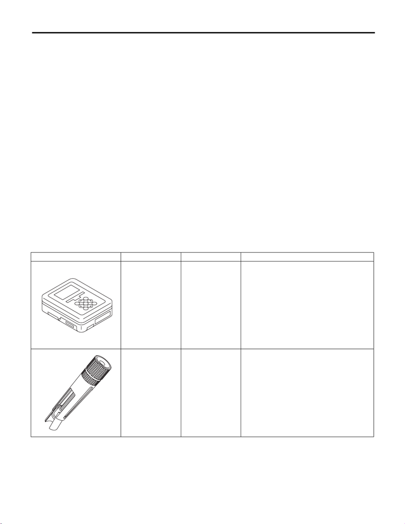

FU(w/o STI)-13

General Description

FUEL INJECTION (FUEL SYSTEMS)

C: CAUTION

• Prior to starting work, pay special attention to the following:

1. Always wear work clothes, a work cap, and protective shoes. Additionally, wear a helmet, protective

goggles, etc. if necessary.

2. Protect the vehicle using a seat cover, fender cover, etc.

3. Prepare the service tools, clean cloth, containers to catch grease and oil, etc.

• Place “NO OPEN FLAMES” signs near the working area.

• Prepare a container and cloth to prevent scattering of fuels when performing work where fuels can be

spilled. If the oil spills, wipe it off immediately to prevent from penetrating into floor or flowing out for environ-

mental protection.

• Vehicle components are extremely hot immediately after driving. Be wary of receiving burns from heated

parts.

• When performing a repair, identify the cause of trouble and avoid unnecessary removal, disassembly and

replacement.

• Before disconnecting connectors of sensors or units, be sure to disconnect the ground cable from battery.

• Always use the jack-up point when the shop jacks or rigid racks are used to support the vehicle.

• Remove contamination including dirt and corrosion before removal, installation, disassembly or assembly.

• Keep the removed parts in order and protect them from dust and dirt.

• All removed parts, if to be reused, should be reinstalled in the original positions with attention to the correct

directions, etc.

• Bolts, nuts and washers should be replaced with new parts as required.

• Follow all government and local regulations concerning disposal of refuse when disposing fuel.

D: PREPARATION TOOL

1. SPECIAL TOOL

ILLUSTRATION TOOL NUMBER DESCRIPTION REMARKS

1B022XU0 SUBARU SELECT

MONITOR III KIT

Used for draining fuel and each inspection.

18356AA000 INJECTOR

REMOVER

Used for removing the injector.

ST1B022XU0

ST18356AA000

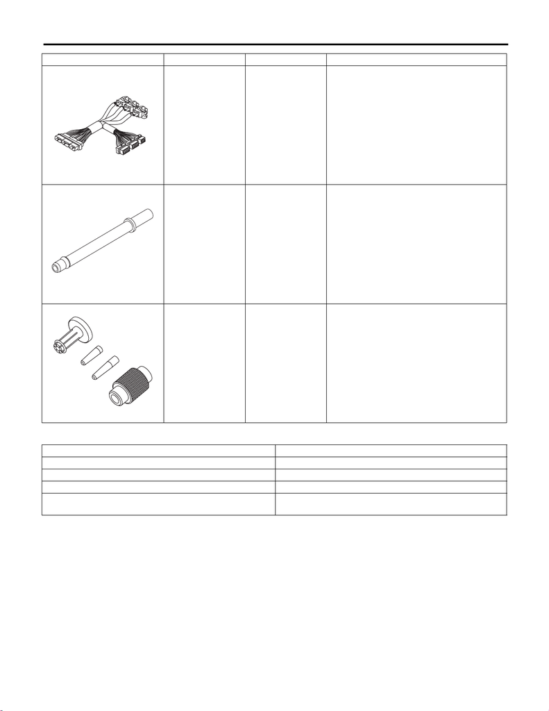

FU(w/o STI)-14

General Description

FUEL INJECTION (FUEL SYSTEMS)

2. GENERAL TOOL

18460AA030 CHECK BOARD Used for inspecting the fuel system.

18471AA000 FUEL PIPE

ADAPTER

Used for draining fuel.

18683AA000 INJECTOR SEAL

INSTALLER

Used for installing the injector seal.

TOOL NAME REMARKS

Circuit tester Used for measuring resistance and voltage.

Oscilloscope Used for inspecting the waveform of each sensor.

TORX PLUS

®

bit 40IP Used for removing and installing high-pressure fuel pump.

Mighty Vac Used for inspecting the manifold absolute pressure and intake

air temperature sensor.

ILLUSTRATION TOOL NUMBER DESCRIPTION REMARKS

ST18460AA030

ST18471AA000

ST18683AA000